# qPCR re-extraction inhibition results

18 October 2023

Some of the amalga samples are inhibited and I’m re-running the 2021 samples and May, 5, 2022 samples to test for inhibition using an IPC.

```r
library(readxl)
library(patchwork)
library(tidyverse)
```

## Quick look at 2021 samples to choose a subset to test for inhibition

```r
# read in the extraction database metadata
metadata <- read_xlsx("../data/extraction_database.xlsx", sheet = "metadata")

# read in the combined qPCR results
qpcr <- read_xlsx("../data/qPCR_results_combined.xlsx")

# organize color palette
mycols <- c("coral3", "cadetblue4")
```

### Metadata QC

```r
# clean up the metadata format and variable names
frsh_meta <- metadata %>%
  mutate(tide = ifelse(`Sample Code` == "AM", "incoming", "outgoing")) %>%
  mutate(tide = ifelse(is.na(`Sample Code`) | `Sample Code` == "Creek", NA, tide)) %>%
  rename(sample = `Extraction ID`, location = `Sample Code`, label = `Sample Label`, type = `Sample_type`) %>%
  # distance needs to be a numeric variable without meters attached
  mutate(dist_grp = ifelse(location %in% c("PM", "AM"), label, NA))

# strip off the meters on dist_grp so we can order them properly
frsh_meta$dist_grp <- gsub("[^0-9.-]", "", frsh_meta$dist_grp)

# make another variable that is numeric distance (not character)
clean_meta <- frsh_meta %>%
  mutate(distance = as.numeric(dist_grp)) %>%
  # remove some of the unneeded variables
  dplyr::select(sample, location, label, type, tide, dist_grp, distance) %>%
  # add info to the creek samples
  mutate(label = ifelse(location == "Creek", "freshwater", label)) %>%
  mutate(label = ifelse(is.na(location), "blank", label))


clean_meta
```

| sample | location | label | type | tide | dist_grp | distance |
| --- | --- | --- | --- | --- | --- | --- |
| e00019 | PM | 1120m | eDNA | outgoing | 1120 | 1120 |
| e00020 | PM | 1120m | eDNA | outgoing | 1120 | 1120 |
| e00021 | PM | 1120m | eDNA | outgoing | 1120 | 1120 |
| e00022 | PM | 1200m | eDNA | outgoing | 1200 | 1200 |
| e00023 | PM | 1200m | eDNA | outgoing | 1200 | 1200 |
| e00024 | PM | 1200m | eDNA | outgoing | 1200 | 1200 |
| e00025 | PM | 1280m | eDNA | outgoing | 1280 | 1280 |
| e00026 | PM | 1280m | eDNA | outgoing | 1280 | 1280 |
| e00027 | PM | 1280m | eDNA | outgoing | 1280 | 1280 |
| e00028 | PM | 1360m | eDNA | outgoing | 1360 | 1360 |

[output cut: 162 more lines]

## Check 2021 samples for inhibition

23 October 2023

A plate of 2021 samples with high-med-low-no amplification with the IPC to check for inhibition.

In actuality, I added 2 ul of each standard to each reaction, so if the gBlock standard was at 10,000 copies for 1 ul, that would translate to 20,000 copies in 2 ul. I’m not going to worry about that particularly in this moment, but it’s something to keep in mind.

This is not true for the multiplexed Moa and Oke standards because 2 ul should constitute 1 ul of each standard.

However, there were 2 ul of each DNA extract added to each reaction, so to get a per 1 ul copy number, I would need to divide the quantity by 2.

```r
# read in temp sample info
# test2021 <- read_xlsx("../data/qpcr/2023-10-20_AmalgaInhibitionTest2021samples.xlsx", sheet = "Results", skip = 33)
#
# test2021$`Ct Mean` <- round(test2021$`Ct Mean`,3)
```

Quick look at efficiency:

```r
# E <- test2021 %>%
#   mutate(efficiency = -1 + 10^ (-1/Slope))
#
# E %>% filter(Task == "STANDARD" &
#                `Target Name` == "Oke_COI")
```

```r
# p <- test2021 %>%
#   filter(Task == "UNKNOWN") %>%
#   ggplot(aes(x =`Sample Name` , y = `Ct Mean` , color = `Target Name`)) +
#   geom_point() +
#   theme_bw() +
#   theme(
#     axis.text.x = element_text(angle = 90)
#   ) +
#   #facet_grid(rows = vars(`Target Name`))  +
#   scale_y_continuous(breaks = seq(22,40, 1))
#
# p + annotate("rect", xmin = "e00025", xmax = "e00190", ymin = 26, ymax = 28, alpha = 0.2, fill = "salmon")
#
# ggsave("pdf_outputs/inhibitionTest2021samples.pdf", width = 6, height = 4)
```

1. Confirm that the Moa IPC is at ~1000 copies:

```r
# What's the CT value for 1000 copies?
# test2021 %>%
#   filter(`Target Name` == "Moa_IPC" &
#            Task == "STANDARD")
```

According to this, the 1000 standard is at ~26 CT.

## plate 2 and plate 3

```r
# plate2 <- read_xlsx("../data/qpcr/2023-10-26_amalga_inhibition_test_plate2.xlsx", sheet = "Results", skip = 32)
#
# plate2 %>%
#   filter(Task == "STANDARD" &
#            `Target Name` == "Moa_IPC" &
#            Quantity == "1000")
```

Mean value is 26.18; so anything from 26-28.18 should be ok.

```r
# test for inhibition in plate 2
# p2 <- plate2 %>%
#   filter(Task != "STANDARD") %>%
#   ggplot(aes(x = reorder(`Sample Name`, Well), y = `Ct Mean` , color = `Target Name`)) +
#   geom_point() +
#   theme_bw() +
#   theme(
#     axis.text.x = element_text(angle = 90)
#   ) +
#   #facet_grid(rows = vars(`Target Name`))  +
#   scale_y_continuous(breaks = seq(18,45, 1))
#
# p2 + annotate("rect", xmin = "1", xmax = "Sample D", ymin = 26.18, ymax = 28.18, alpha = 0.2, fill = "salmon")
```

Which samples are those?

```r
# plate2 %>%
#   filter(Task != "STANDARD" &
#            `Target Name` == "Moa_IPC" &
#            `Ct Mean` > 28.18) %>%
#   group_by(`Sample Name`) %>%
#   tally()
```

7 inhibited samples in Plate 2

```r
# plate3 <- read_xlsx("../data/qpcr/2023-10-26_amalga_inhibition_test_plate3.xlsx", sheet = "Results", skip = 34)
#
# plate3 %>%
#   filter(Task == "STANDARD" &
#            `Target Name` == "Moa_IPC" &
#            Quantity == "1000")
```

CT is higher than on plate 2: 28, which maybe isn’t surprising since I used a different dilution of Moa at 10^3. Probably worth re-quantifying and making a new 1000 copy dilution.

```r
# test for inhibition in plate 2
# p3 <- plate3 %>%
#   filter(Task != "STANDARD") %>%
#   ggplot(aes(x = reorder(`Sample Name`, Well), y = `Ct Mean` , color = `Target Name`)) +
#   geom_point() +
#   theme_bw() +
#   theme(
#     axis.text.x = element_text(angle = 90)
#   ) +
#   #facet_grid(rows = vars(`Target Name`))  +
#   scale_y_continuous(breaks = seq(18,45, 1))
#
# p3 + annotate("rect", xmin = "1", xmax = "Sample D", ymin = 28, ymax = 30, alpha = 0.2, fill = "salmon")
```

Mostly uninhibited, which is good.

```r
# plate3 %>%
#   filter(Task != "STANDARD" &
#            `Target Name` == "Moa_IPC" &
#            `Ct Mean` > 30) %>%
#   group_by(`Sample Name`) %>%
#   tally()
```

Two of the four samples are really close to the edge of inhibition or not.

First three plates: 6, 7, and 4 inhibited samples.

```r
qpcr_inhibition_test <- function(file){

        plate <- read_xlsx(file, sheet = "Results", skip = 34)

        ipc_ct_val <- plate %>%
          filter(Task == "STANDARD" &
                   `Target Name` == "Moa_IPC" &
                   Quantity == "1000")

        print(ipc_ct_val)

        # test for inhibition
        p <- plate %>%
          filter(Task != "STANDARD") %>%
          ggplot(aes(x = reorder(`Sample Name`, Well), y = `Ct Mean` , color = `Target Name`)) +
          geom_point() +
          theme_bw() +
          theme(
            axis.text.x = element_text(angle = 90)
          ) +
          #facet_grid(rows = vars(`Target Name`))  +
          scale_y_continuous(breaks = seq(18,45, 1))

        # display plot
        plot <- p + annotate("rect", xmin = "1", xmax = "NTC", ymin = ipc_ct_val$`Ct Mean`, ymax = (ipc_ct_val$`Ct Mean`)+2, alpha = 0.2, fill = "salmon")

        print(plot)

        # plot the standards
        std_plot <- plate %>%
          filter(Task == "STANDARD") %>%
          ggplot(aes(x = reorder(`Sample Name`, Well), y = `Ct Mean` , color = `Target Name`)) +
          geom_point() +
          theme_bw() +
          theme(
          axis.text.x = element_text(angle = 90)
        ) +
        scale_y_continuous(breaks = seq(18,40, 1))

        print(std_plot)

        # which samples are inhibited?
        plate %>%
        filter(Task != "STANDARD" &
           `Target Name` == "Moa_IPC" &
           `Ct Mean` > ipc_ct_val$`Ct Mean`+2) %>%
          dplyr::select(`Sample Name`, `Ct Mean`) %>%
          unique()

}
```

```r
# plate 4
#qpcr_inhibition_test("../data/qpcr/2023-10-27_Amalga_inhibition_test_plate4.xlsx")
```

Ignoring the NTC, there are seven inhibited samples from plate 4.

```r
# plate 5
#qpcr_inhibition_test("../data/qpcr/2023-10-27_Amalga_inhibition_test_plate5.xlsx")
```

13 inhibited samples

```r
# plate 6
#qpcr_inhibition_test("../data/qpcr/2023-10-27_Amalga_inhibition_test_plate6.xlsx")
```

Really? All of the samples from Plate 6?

```r
#qpcr_inhibition_test("../data/qpcr/2023-10-27_Amalga_inhibition_test_plate7.xlsx")
```

None of those look particularly inhibited, but I’ll go with the three that are clearly outside the 2 Ct range.

Ok, so the samples that need to be diluted and re-run are:

e00161 e00169 e00180

All samples from plate 6

e00104  
e00114  
e00123  
e00105  
e00115  
e00124  
e00106  
e00126  
e00127  
e00131 e00132  
e00122  
e00133 e00078  
e00086  
e00096  
e00097  
e00099  
e00102  
e00103 e00050  
e00060  
e00069  
e00070 e00019  
e00026  
e00028  
e00034  
e00035  
e00037 e00038 e00025  
e00029  
e00056  
e00128 e00142  
e00190

## Combine data

Patterns across samples of inhibition?? Look at metadata.

Read in all combined data:

```r
file_path <- "../data/qpcr/"

file_path %>%
  list.files() %>%
  .[str_detect(., ".xlsx")] -> xlsx_file_names

# Load everything into the Global Environment
xlsx_file_names %>%
  purrr::map(function(file_name){ # iterate through each file name

  read_xlsx(paste0(file_path, file_name), sheet = "Results", skip = 34)

}) -> df_list_read2 # Assign to a list

# combine all files into one df
# nothing was done to the quantities in this df
all_plates2021 <- bind_rows(df_list_read2, .id = "plate") %>%
    mutate(efficiency = -1 + 10^ (-1/Slope))

# calculate efficiency for all plates
all_plates2021 %>%
  group_by(`Target Name`) %>%
  summarise(E = mean(efficiency))
```

| Target Name | E |
| --- | --- |
| Moa_IPC | 0.9286335 |
| Oke_COI | 0.9065930 |
| NA | NA |

```r
NA
```

```r
# but I'm going to want to add a column that designates whether the sample is inhibited or not.
qpcr_data_w_metadata <- all_plates2021 %>%
  left_join(., clean_meta, by = c("Sample Name" = "sample"))

qpcr_data_w_metadata %>%
  filter(Task == "UNKNOWN" &
           CT != "Undetermined") %>%
  dplyr::select(`Sample Name`, `Ct Mean`, dist_grp, tide, distance) %>%
  unique()
```

| Sample Name | Ct Mean | dist_grp | tide | distance |
| --- | --- | --- | --- | --- |
| e00056 | 28.35711 | 160 | incoming | 160 |
| e00056 | 25.63535 | 160 | incoming | 160 |
| e00128 | 28.59718 | 2000 | incoming | 2000 |
| e00190 | 28.70714 | 1680 | outgoing | 1680 |
| e00089 | 26.86595 | NA | NA | NA |
| e00125 | 27.43735 | 1920 | incoming | 1920 |
| e00189 | 27.16155 | 1680 | outgoing | 1680 |
| e00134 | 26.48943 | 0 | outgoing | 0 |
| e00134 | 25.47451 | 0 | outgoing | 0 |
| e00120 | 27.58316 | 1840 | incoming | 1840 |

[output cut: 266 more lines]

```r
NA
```

## Quick check on diluted inhibited samples

Plate 1

```r
#qpcr_inhibition_test("../data/diluted_qpcr/2023-10-31_Amalga_inhibited_diluted_plate1.xlsx")
```

In that first plate, there are two samples that are still potentially (barely) inhibited.

A bunch of the ones that amplified are out past a Ct of 35, which would be <10 copies.

```r
#qpcr_inhibition_test("../data/diluted_qpcr/2023-10-31_Amalga_inhibited_diluted_plate2.xlsx")
```

None of the samples in plate 2 remain inhibited post-dilution. Excellent.

For the diluted samples, I’ll want to multiply the quantity by 10 thanks to the 1:10 dilution factor.

```r
#qpcr_inhibition_test("../data/diluted_qpcr/2023-10-31_Amalga_inhibited_diluted_plate3.xlsx")
```

two samples that are barely inhibited… look at the field replicates to get a sense for if the quantity if far off due to persistent inhibition.

Similar to the undiluted plates, I’ll want to read in all three results documents and then analyze them in tandem.

### Diluted samples from 2021

```r
diluted_file_path <- "../data/diluted_qpcr/"

diluted_file_path %>%
  list.files() %>%
  .[str_detect(., ".xlsx")] -> xlsx_file_names_diluted

# Load everything into the Global Environment
xlsx_file_names_diluted %>%
  purrr::map(function(file_name){ # iterate through each file name

  read_xlsx(paste0(diluted_file_path, file_name), sheet = "Results", skip = 34)

}) -> df_list_read3 # Assign to a list

diluted_plates <- bind_rows(df_list_read3, .id = "plate")

# multiple quantities by 10 because of 1:10 dilution factor
diluted_plates_10x <- diluted_plates %>%
  mutate(quant = Quantity*10) %>%
  mutate(inhibited = "yes")

# list of inhibited samples
inhibited_list <- diluted_plates_10x %>%
  filter(Task =="UNKNOWN") %>%
  dplyr::select(`Sample Name`) %>%
  unique()
```

### Combined data from inhibited samples and uninhibited samples

```r
combined_data <- all_plates2021 %>%
  anti_join(., inhibited_list) %>%
  bind_rows(., diluted_plates_10x) %>%
  filter(Task == "UNKNOWN" &
           `Target Name` == "Oke_COI") %>%
  #select(`Sample Name`, `Quantity Mean`, quant) %>%
  mutate(quant = ifelse(is.na(quant), Quantity, quant)) %>%
  #filter(!is.na(quant)) %>%
  mutate(quant_per_ul = quant/2)
plotA_2021 <- combined_data %>%
  left_join(., clean_meta, by = c("Sample Name" = "sample")) %>%
  filter(!is.na(tide)) %>%
  ggplot(aes(x = distance, y = log10(quant_per_ul), color = tide, shape = tide)) +
  geom_point(size = 2, alpha = 0.65) +
  geom_smooth(method = "lm", se = F) +
  #facet_grid(rows = vars(tide)) +
  theme_bw() +
   scale_shape_manual(values = c(16, 18)) +
  scale_color_manual(values = mycols) +
  labs(x = "Distance from pens (m)",
       y = "DNA copy number/uL (log10)",
       color = "Tide",
       shape = "Tide") +
  theme(
    #axis.title.x = element_text(margin = margin(t = 10)),
    axis.title.x = element_blank(),
    axis.title.y = element_text(margin = margin(r = 10)),
        legend.position = c(0.8, 0.8)
  )

#ggsave("pdf_outputs/Amalga2021_qPCR_by_tide.png", width = 5, height = 4)
```

At incoming vs. outgoing tides, the concentration of chum salmon DNA at ~1000 m looks different. Make a note of the LOD/LOQ in the figure legend, but include detections below the LOQ on the plot.

Make a plot of the CV for each distance:

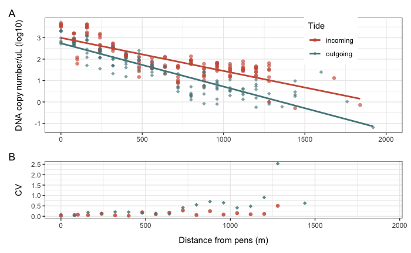

```r
plotB_2021 <- combined_data %>%
  left_join(., clean_meta, by = c("Sample Name" = "sample")) %>%
  filter(!is.na(tide) &
           !is.na(quant_per_ul)) %>%
  group_by(distance, tide) %>%
  mutate(sd = sd(log10(quant_per_ul))) %>%
  mutate(mean = mean(log10(quant_per_ul))) %>%
  dplyr::select(distance, sd, mean, tide) %>%
  unique() %>%
  mutate(cv = sd/mean) %>%
  ggplot(aes(x = distance, y = cv, color = tide, shape = tide)) +
  geom_point(size = 2, alpha = 0.85) +
  theme_bw() +
   scale_shape_manual(values = c(16, 18)) +
  scale_color_manual(values = mycols) +
  labs(x = "Distance from pens (m)",
       y = "CV",
       color = "Tide",
       shape = "Tide") +
  theme(
    axis.title.x = element_text(margin = margin(t = 10)),
    axis.title.y = element_text(margin = margin(r = 10)),
        #legend.position = c(0.8, 0.8)
    legend.position = "none"
  )

#ggsave("pdf_outputs/Amalga2021_qPCR_by_tideCV.png", width = 5, height = 4)

# combine plots A and B

plotA_2021 + plotB_2021 + plot_layout(ncol = 1, heights = c(2,1)) +
  plot_annotation(tag_levels = "A")

ggsave("pdf_outputs/Amalga2021_transect_and_CV.png", width = 5, height = 6)
```

Which samples are inhibited?

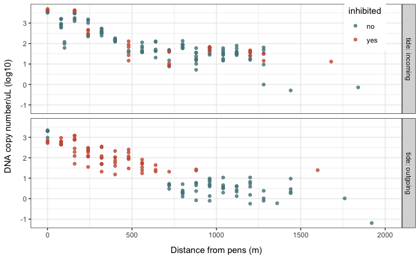

```r
combined_data %>%
  left_join(., clean_meta, by = c("Sample Name" = "sample")) %>%
    filter(!is.na(tide)) %>%
  mutate(inhibited = ifelse(is.na(inhibited), "no", "yes")) %>%
  ggplot(aes(x = distance, y = log10(quant_per_ul))) +
  geom_point(aes(color = inhibited), alpha = 0.8) +
  facet_grid(rows = vars(tide), labeller = label_both) +
  theme_bw() +
  labs(x = "Distance from pens (m)",
       y = "DNA copy number/uL (log10)") +
  theme(
    axis.title.x = element_text(margin = margin(t = 10)),
    axis.title.y = element_text(margin = margin(r = 10)),
    legend.position = c(0.9, 0.9)
  ) +
  scale_color_manual(values = c("cadetblue4", "coral3"))

ggsave("pdf_outputs/Amalga2021_qPCR_inhibition_by_tide.png", width = 6, height = 5)
```

Notes about inhibition: - generally closer to the nearshore - substantially more inhibition during outgoing tide

```r
combined_data %>%
  left_join(., clean_meta, by = c("Sample Name" = "sample")) %>%
  filter(inhibited == "yes")%>%
  group_by(`Sample Name`, tide) %>%
  tally() %>%
  group_by(tide) %>%
  tally()
```

| tide | n |
| --- | --- |
| incoming | 23 |
| outgoing | 40 |

```r
combined_data %>%
  left_join(., clean_meta, by = c("Sample Name" = "sample")) %>%
  filter(tide == "outgoing" & distance < 750) %>%
  group_by(inhibited) %>%
  tally() %>%
  mutate(n/3)
```

| inhibited | n | n/3 |
| --- | --- | --- |
| yes | 78 | 26 |
| NA | 12 | 4 |

```r
26/40
```

```
[1] 0.65
```

1. Okay, if I wanted to re-run the qPCR for the 2022 samples (all or part), how many would that be? (171 samples)

```r
171/24
```

```
[1] 7.125
```

2. LOD/LOQ calculations - can I use the standard curves from the plates I already ran? Potential concern with low PCR efficiency?

LOD: six 4-fold serial dilutions with 8-24 replicates per dilution. Calculate lowest initial concentration with 95% detection. LOQ: same dilution series: lowest initial concentration with CV < 35%

If I wanted to go back and use my existing standards for the calculations… Standards from the dilution plates too

```r
# but the first plate didn't have Moa at 10^6 copies, so let's drop that one from this calculation
standards <- all_plates2021 %>%
  filter(Task == "STANDARD" &
           `Target Name` == "Oke_COI" &
           CT != "Undetermined" &
           !`Sample Name` %in% c("Sample 1", "std_10"))

# add dilution plate standards
dil_stds <- diluted_plates_10x %>%
  filter(Task == "STANDARD" &
           `Target Name` == "Oke_COI")

stds_combo <- bind_rows(standards, dil_stds)

# make the CT numeric
stds_combo$CT <- as.numeric(stds_combo$CT)
# create linear model
lm_fit <- lm(data = stds_combo, CT ~ log10(Quantity))

summary(lm_fit)
```

```
Call:
lm(formula = CT ~ log10(Quantity), data = stds_combo)

Residuals:
    Min      1Q  Median      3Q     Max
-1.7065 -0.3952 -0.1330  0.2727  1.9071

Coefficients:
                Estimate Std. Error t value Pr(>|t|)
(Intercept)     38.83493    0.13699   283.5   <2e-16 ***
log10(Quantity) -3.60299    0.03554  -101.4   <2e-16 ***
---
Signif. codes:  0 ‘***’ 0.001 ‘**’ 0.01 ‘*’ 0.05 ‘.’ 0.1 ‘ ’ 1

Residual standard error: 0.6599 on 137 degrees of freedom
  (7 observations deleted due to missingness)
Multiple R-squared:  0.9868,    Adjusted R-squared:  0.9867
F-statistic: 1.028e+04 on 1 and 137 DF,  p-value: < 2.2e-16
```

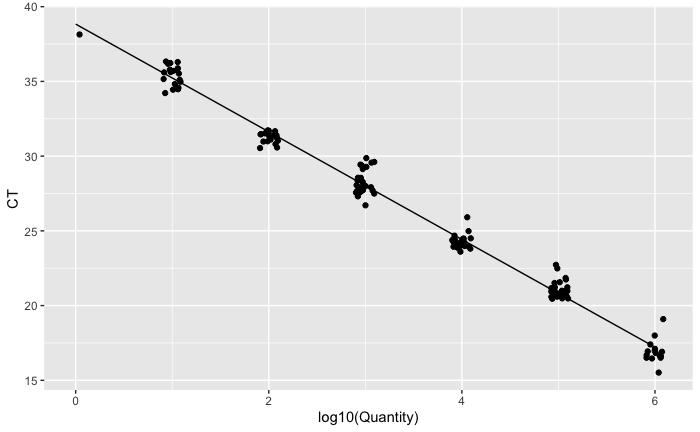

```r
# plot that model
stds_combo %>%
  ggplot(aes(x = log10(Quantity), y = CT)) +
  geom_jitter(width = 0.1, height = 0.01) +
  #geom_smooth(method = "lm")
  geom_line(data = fortify(lm_fit), aes(x = `log10(Quantity)`, y = .fitted))
```

```r
NA
NA
NA
```

```r
# check coefficient of variation
stds_combo %>%
  group_by(Quantity) %>%
  summarise(cv = sd(CT)/mean(CT)*100)
```

| Quantity | cv |
| --- | --- |
| 1e+00 | NA |
| 1e+01 | NA |
| 1e+02 | 1.176022 |
| 1e+03 | 2.856137 |
| 1e+04 | 1.756102 |
| 1e+05 | 2.666843 |
| 1e+06 | 4.721882 |

```r
# output test standards file for LoD calculator
std_for_lod <- stds_combo %>%
  dplyr::select(`Well Position`, Reporter, `Sample Name`, CT, Quantity, `Target Name`) %>%
  rename(Well = `Well Position`, Fluor = Reporter, Sample = `Sample Name`, Cq = CT, SQ = Quantity, Target = `Target Name`)
```

## Compare linear regression models

```r
# qpcr_w_meta <- combined_data %>%
#   left_join(., clean_meta, by = c("Sample Name" = "sample"))
#
# qpcr_w_meta %>%
#   filter(!is.na(tide)) %>%
#   ggplot(aes(x = distance, y = log10(quant_per_ul), color = tide)) +
#   geom_point() +
#   geom_smooth(method = "lm", se = F) +
#   theme_bw() +
#   labs(x = "Distance from pens (m)",
#        y = "DNA copy number/uL (log10)") +
#   theme(
#     axis.title.x = element_text(margin = margin(t = 10)),
#     axis.title.y = element_text(margin = margin(r = 10))
#   )
#
# # model 1: copy number and distance
# mod1 <- lm(data = qpcr_w_meta, log10(quant_per_ul) ~ distance)
#
# # model 2: distance and tide
# mod2 <- lm(data = qpcr_w_meta, log10(quant_per_ul) ~ distance + tide)
#
# # now compare the models with anova
# anova(mod1, mod2)
```

```r
# model fit
#summary(mod2)
```

# 2022 samples

first test plate - all samples diluted 1:10

| Well | Well Position | Omit | Sample Name | Target Name | Task | Reporter | Quencher | CT | Ct Mean | Ct SD | Quantity | Quantity Mean | Quantity SD | Automatic Ct Threshold | Ct Threshold | Automatic Baseline | Baseline Start | Baseline End | Comments | Y-Intercept | R(superscript 2) | Slope | Amp Score | Cq Conf | Amp Status | EXPFAIL | HIGHSD | NOAMP |
| --- | --- | --- | --- | --- | --- | --- | --- | --- | --- | --- | --- | --- | --- | --- | --- | --- | --- | --- | --- | --- | --- | --- | --- | --- | --- | --- | --- | --- |
| 37 | D1 | false | 1000 | Moa_IPC | STANDARD | VIC | NFQ-MGB | 27.726059 | 27.07905 | 0.5625377 | 1000 | 1000 | NA | false | 0.03 | true | 3 | 25 | NA | 38.3298 | 0.9899 | -3.6657 | 1.399880 | 0.6927181 | Amp | N | Y | N |
| 38 | D2 | false | 1000 | Moa_IPC | STANDARD | VIC | NFQ-MGB | 26.80537 | 27.07905 | 0.5625377 | 1000 | 1000 | NA | false | 0.03 | true | 3 | 24 | NA | 38.3298 | 0.9899 | -3.6657 | 1.428690 | 0.6932895 | Amp | N | Y | N |
| 39 | D3 | false | 1000 | Moa_IPC | STANDARD | VIC | NFQ-MGB | 26.705719 | 27.07905 | 0.5625377 | 1000 | 1000 | NA | false | 0.03 | true | 3 | 24 | NA | 38.3298 | 0.9899 | -3.6657 | 1.419544 | 0.7372164 | Amp | N | Y | N |

| Sample Name | Ct Mean |
| --- | --- |
| e01192 | 29.22008 |
| e01256 | 29.28878 |
| e01264 | 30.14478 |
| e01271 | 29.56754 |

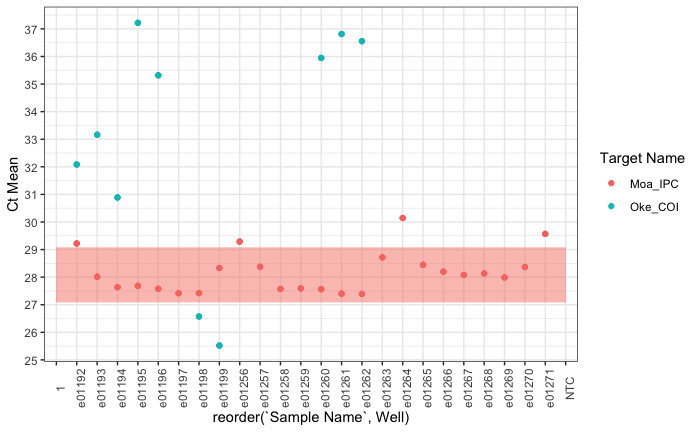

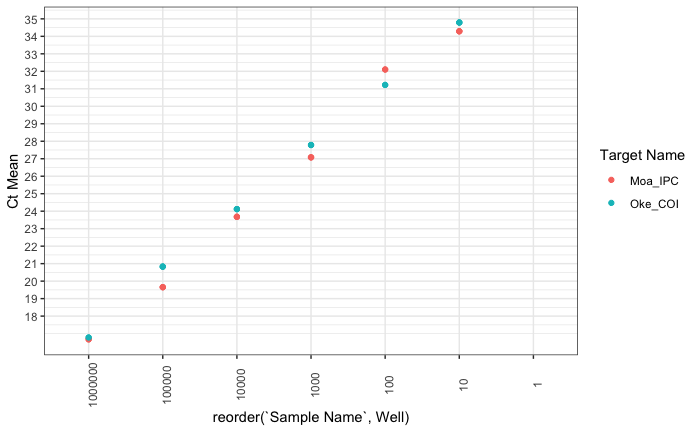

```r
qpcr_inhibition_test(file = "../data/qpcr/2022/2023-11-03_Amalga2022_inhibition_test_plate1.xlsx")
```

second plate

```r
qpcr_inhibition_test("../data/qpcr/2022/2023-11-03_Amalga2022_inhibition_test_plate2.xlsx")
```

| Well | Well Position | Omit | Sample Name | Target Name | Task | Reporter | Quencher | CT | Ct Mean | Ct SD | Quantity | Quantity Mean | Quantity SD | Automatic Ct Threshold | Ct Threshold | Automatic Baseline | Baseline Start | Baseline End | Comments | Y-Intercept | R(superscript 2) | Slope | Amp Score | Cq Conf | Amp Status | EXPFAIL | HIGHSD | NOAMP |
| --- | --- | --- | --- | --- | --- | --- | --- | --- | --- | --- | --- | --- | --- | --- | --- | --- | --- | --- | --- | --- | --- | --- | --- | --- | --- | --- | --- | --- |
| 37 | D1 | false | 1000 | Moa_IPC | STANDARD | VIC | NFQ-MGB | 25.249052 | 25.02058 | 0.2014897 | 1000 | 1000 | NA | false | 0.03 | true | 3 | 22 | NA | 36.1167 | 0.994 | -3.6314 | 1.422318 | 0.6776662 | Amp | N | N | N |
| 38 | D2 | false | 1000 | Moa_IPC | STANDARD | VIC | NFQ-MGB | 24.868284 | 25.02058 | 0.2014897 | 1000 | 1000 | NA | false | 0.03 | true | 3 | 22 | NA | 36.1167 | 0.994 | -3.6314 | 1.439029 | 0.6570791 | Amp | N | N | N |
| 39 | D3 | false | 1000 | Moa_IPC | STANDARD | VIC | NFQ-MGB | 24.944405 | 25.02058 | 0.2014897 | 1000 | 1000 | NA | false | 0.03 | true | 3 | 22 | NA | 36.1167 | 0.994 | -3.6314 | 1.431574 | 0.7014686 | Amp | N | N | N |

| Sample Name | Ct Mean |
| --- | --- |
| e01272 | 28.28363 |

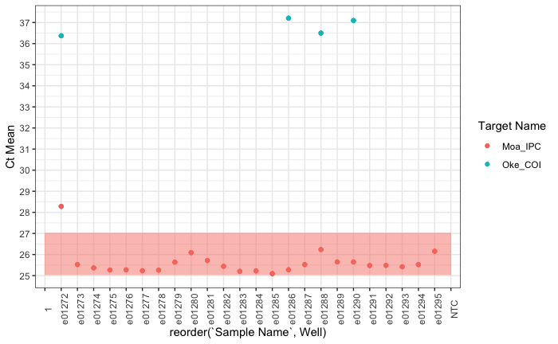

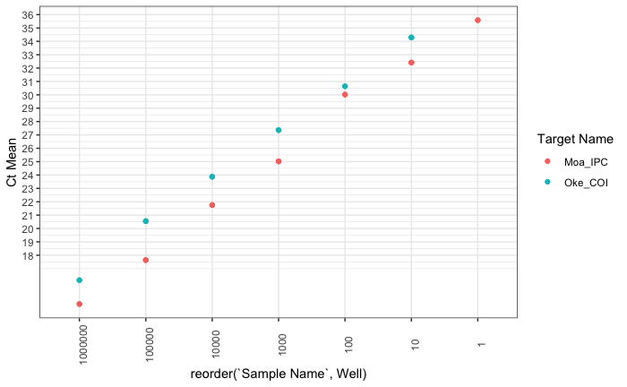

```r
NA
```

Very low amplification at all.

third plate

| Well | Well Position | Omit | Sample Name | Target Name | Task | Reporter | Quencher | CT | Ct Mean | Ct SD | Quantity | Quantity Mean | Quantity SD | Automatic Ct Threshold | Ct Threshold | Automatic Baseline | Baseline Start | Baseline End | Comments | Y-Intercept | R(superscript 2) | Slope | Amp Score | Cq Conf | Amp Status | EXPFAIL | HIGHSD | NOAMP |
| --- | --- | --- | --- | --- | --- | --- | --- | --- | --- | --- | --- | --- | --- | --- | --- | --- | --- | --- | --- | --- | --- | --- | --- | --- | --- | --- | --- | --- |
| 37 | D1 | false | 1000 | Moa_IPC | STANDARD | VIC | NFQ-MGB | 26.426268 | 26.11902 | 0.2661983 | 1000 | NA | NA | false | 0.03 | true | 3 | 24 | NA | 37.2693 | 0.9873 | -3.6055 | 1.412184 | 0.6956813 | Amp | N | N | N |
| 38 | D2 | false | 1000 | Moa_IPC | STANDARD | VIC | NFQ-MGB | 25.957737 | 26.11902 | 0.2661983 | 1000 | NA | NA | false | 0.03 | true | 3 | 23 | NA | 37.2693 | 0.9873 | -3.6055 | 1.431813 | 0.6733253 | Amp | N | N | N |
| 39 | D3 | false | 1000 | Moa_IPC | STANDARD | VIC | NFQ-MGB | 25.973042 | 26.11902 | 0.2661983 | 1000 | NA | NA | false | 0.03 | true | 3 | 23 | NA | 37.2693 | 0.9873 | -3.6055 | 1.422721 | 0.6203931 | Amp | N | N | N |

| Sample Name | Ct Mean |
| --- | --- |
| e01312 | 28.26190 |
| e01319 | 29.17768 |

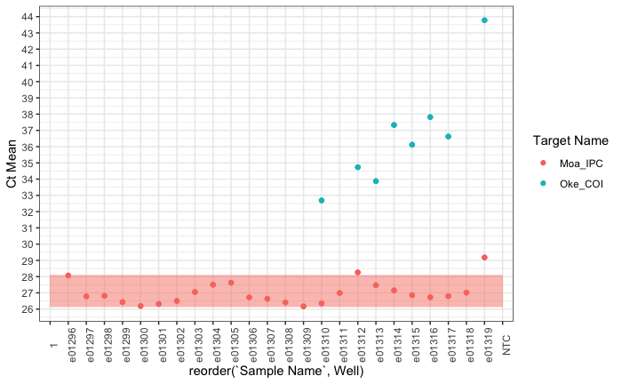

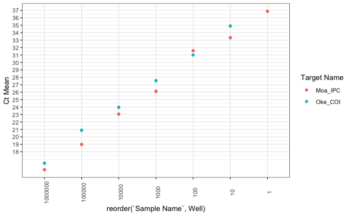

```r
qpcr_inhibition_test("../data/qpcr/2022/2023-11-03_Amalga2022_inhibition_test_plate3.xlsx")
```

| Well | Well Position | Omit | Sample Name | Target Name | Task | Reporter | Quencher | CT | Ct Mean | Ct SD | Quantity | Quantity Mean | Quantity SD | Automatic Ct Threshold | Ct Threshold | Automatic Baseline | Baseline Start | Baseline End | Comments | Y-Intercept | R(superscript 2) | Slope | Amp Score | Cq Conf | Amp Status | EXPFAIL | HIGHSD | NOAMP |
| --- | --- | --- | --- | --- | --- | --- | --- | --- | --- | --- | --- | --- | --- | --- | --- | --- | --- | --- | --- | --- | --- | --- | --- | --- | --- | --- | --- | --- |
| 37 | D1 | false | 1000 | Moa_IPC | STANDARD | VIC | NFQ-MGB | 26.667168 | 26.73074 | 0.2873006 | 1000 | NA | NA | false | 0.03 | true | 3 | 24 | NA | 37.6628 | 0.9826 | -3.4166 | 1.423235 | 0.6692863 | Amp | N | N | N |
| 38 | D2 | false | 1000 | Moa_IPC | STANDARD | VIC | NFQ-MGB | 27.044498 | 26.73074 | 0.2873006 | 1000 | NA | NA | false | 0.03 | true | 3 | 24 | NA | 37.6628 | 0.9826 | -3.4166 | 1.426495 | 0.7169162 | Amp | N | N | N |
| 39 | D3 | false | 1000 | Moa_IPC | STANDARD | VIC | NFQ-MGB | 26.480545 | 26.73074 | 0.2873006 | 1000 | NA | NA | false | 0.03 | true | 3 | 24 | NA | 37.6628 | 0.9826 | -3.4166 | 1.418984 | 0.8109475 | Amp | N | N | N |

| Sample Name | Ct Mean |
| --- | --- |
| e01320 | 29.59060 |
| e01328 | 28.82590 |
| e01336 | 29.27438 |
| e01342 | 29.09409 |
| e01335 | 29.39757 |
| e01343 | 30.00209 |

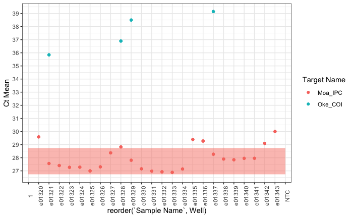

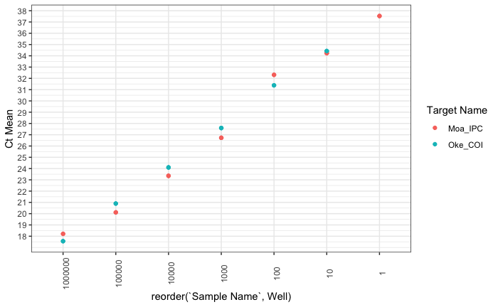

```r
qpcr_inhibition_test("../data/qpcr/2022/2023-11-07_Amalga2022_inhibition_test_plate4.xlsx")
```

| Well | Well Position | Omit | Sample Name | Target Name | Task | Reporter | Quencher | CT | Ct Mean | Ct SD | Quantity | Quantity Mean | Quantity SD | Automatic Ct Threshold | Ct Threshold | Automatic Baseline | Baseline Start | Baseline End | Comments | Y-Intercept | R(superscript 2) | Slope | Amp Score | Cq Conf | Amp Status | EXPFAIL | HIGHSD | NOAMP |
| --- | --- | --- | --- | --- | --- | --- | --- | --- | --- | --- | --- | --- | --- | --- | --- | --- | --- | --- | --- | --- | --- | --- | --- | --- | --- | --- | --- | --- |
| 37 | D1 | false | 1000 | Moa_IPC | STANDARD | VIC | NFQ-MGB | 25.326992 | 25.29038 | 0.03171253 | 1000 | NA | NA | false | 0.03 | true | 3 | 22 | NA | 36.4926 | 0.988 | -3.6345 | 1.414694 | 0.6696936 | Amp | N | N | N |
| 38 | D2 | false | 1000 | Moa_IPC | STANDARD | VIC | NFQ-MGB | 25.271381 | 25.29038 | 0.03171253 | 1000 | NA | NA | false | 0.03 | true | 3 | 22 | NA | 36.4926 | 0.988 | -3.6345 | 1.429572 | 0.7816721 | Amp | N | N | N |
| 39 | D3 | false | 1000 | Moa_IPC | STANDARD | VIC | NFQ-MGB | 25.272774 | 25.29038 | 0.03171253 | 1000 | NA | NA | false | 0.03 | true | 3 | 23 | NA | 36.4926 | 0.988 | -3.6345 | 1.424693 | 0.7159451 | Amp | N | N | N |

| Sample Name | Ct Mean |
| --- | --- |
| e01366 | 27.76188 |

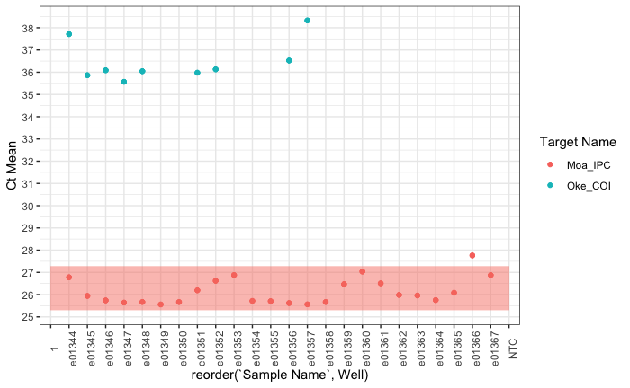

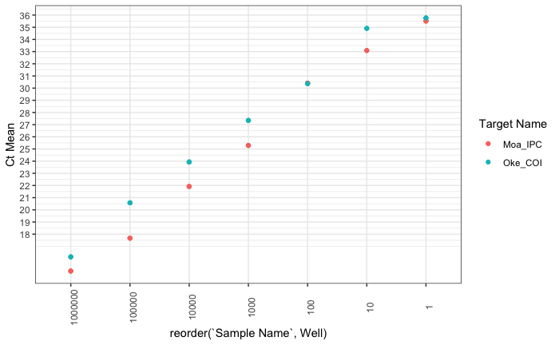

```r
qpcr_inhibition_test("../data/qpcr/2022/2023-11-07_Amalga2022_inhibition_test_plate5.xlsx")
```

| Well | Well Position | Omit | Sample Name | Target Name | Task | Reporter | Quencher | CT | Ct Mean | Ct SD | Quantity | Quantity Mean | Quantity SD | Automatic Ct Threshold | Ct Threshold | Automatic Baseline | Baseline Start | Baseline End | Comments | Y-Intercept | R(superscript 2) | Slope | Amp Score | Cq Conf | Amp Status | EXPFAIL | HIGHSD | NOAMP |
| --- | --- | --- | --- | --- | --- | --- | --- | --- | --- | --- | --- | --- | --- | --- | --- | --- | --- | --- | --- | --- | --- | --- | --- | --- | --- | --- | --- | --- |
| 37 | D1 | false | 1000 | Moa_IPC | STANDARD | VIC | NFQ-MGB | 26.903688 | 26.6965 | 0.1875959 | 1000 | NA | NA | false | 0.03 | true | 3 | 24 | NA | 38.1008 | 0.9884 | -3.6047 | 1.401113 | 0.6725032 | Amp | N | N | N |
| 38 | D2 | false | 1000 | Moa_IPC | STANDARD | VIC | NFQ-MGB | 26.538153 | 26.6965 | 0.1875959 | 1000 | NA | NA | false | 0.03 | true | 3 | 24 | NA | 38.1008 | 0.9884 | -3.6047 | 1.417633 | 0.6681320 | Amp | N | N | N |
| 39 | D3 | false | 1000 | Moa_IPC | STANDARD | VIC | NFQ-MGB | 26.647678 | 26.6965 | 0.1875959 | 1000 | NA | NA | false | 0.03 | true | 3 | 24 | NA | 38.1008 | 0.9884 | -3.6047 | 1.402751 | 0.7872544 | Amp | N | N | N |

| Sample Name | Ct Mean |
| --- | --- |
| e01384 | 28.73767 |

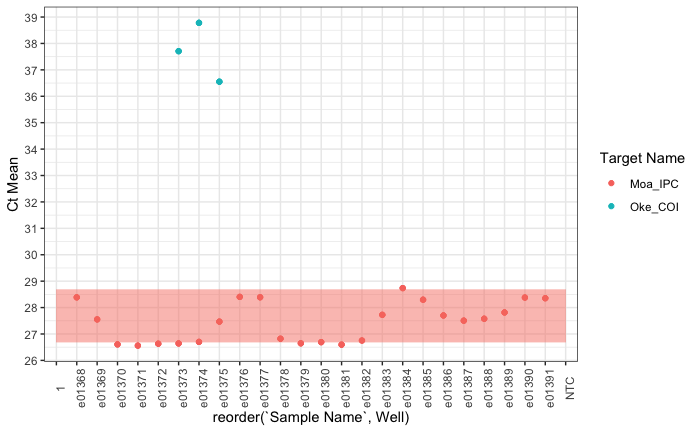

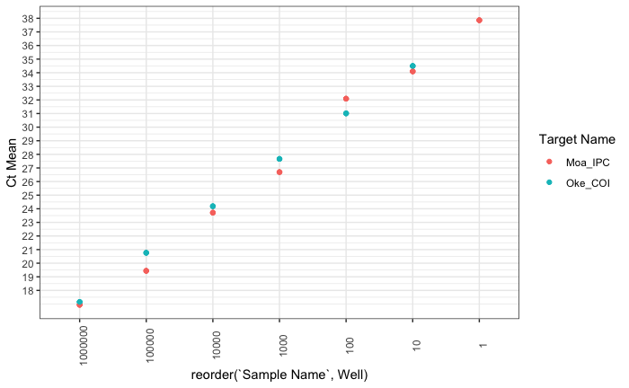

```r
qpcr_inhibition_test("../data/qpcr/2022/2023-11-07_Amalga2022_inhibition_test_plate6.xlsx")
```

| Well | Well Position | Omit | Sample Name | Target Name | Task | Reporter | Quencher | CT | Ct Mean | Ct SD | Quantity | Quantity Mean | Quantity SD | Automatic Ct Threshold | Ct Threshold | Automatic Baseline | Baseline Start | Baseline End | Comments | Y-Intercept | R(superscript 2) | Slope | Amp Score | Cq Conf | Amp Status | EXPFAIL | HIGHSD | NOAMP |
| --- | --- | --- | --- | --- | --- | --- | --- | --- | --- | --- | --- | --- | --- | --- | --- | --- | --- | --- | --- | --- | --- | --- | --- | --- | --- | --- | --- | --- |
| 37 | D1 | false | 1000 | Moa_IPC | STANDARD | VIC | NFQ-MGB | 26.268133 | 25.73331 | 0.4641306 | 1000 | NA | NA | false | 0.03 | true | 3 | 23 | NA | 37.8184 | 0.9905 | -3.7764 | 1.409110 | 0.6826169 | Amp | N | N | N |
| 38 | D2 | false | 1000 | Moa_IPC | STANDARD | VIC | NFQ-MGB | 25.49573 | 25.73331 | 0.4641306 | 1000 | NA | NA | false | 0.03 | true | 3 | 23 | NA | 37.8184 | 0.9905 | -3.7764 | 1.429759 | 0.6682646 | Amp | N | N | N |
| 39 | D3 | false | 1000 | Moa_IPC | STANDARD | VIC | NFQ-MGB | 25.436066 | 25.73331 | 0.4641306 | 1000 | NA | NA | false | 0.03 | true | 3 | 23 | NA | 37.8184 | 0.9905 | -3.7764 | 1.418815 | 0.6939117 | Amp | N | N | N |

| Sample Name | Ct Mean |
| --- | --- |
| e01400 | 27.98903 |
| e01416 | 28.23424 |
| e01432 | 27.84263 |
| e01417 | 28.15416 |
| e01438 | 28.46476 |
| e01439 | 27.97499 |

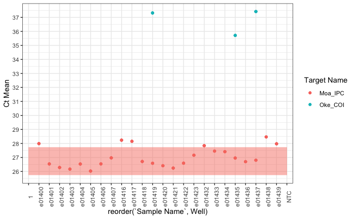

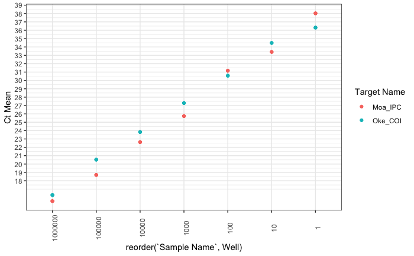

```r
qpcr_inhibition_test("../data/qpcr/2022/2023-11-07_Amalga2022_inhibition_test_plate7.xlsx")
```

```r
qpcr_inhibition_test("../data/qpcr/2022/2023-11-07_Amalga2022_inhibition_test_plate8.xlsx")
```

| Well | Well Position | Omit | Sample Name | Target Name | Task | Reporter | Quencher | CT | Ct Mean | Ct SD | Quantity | Quantity Mean | Quantity SD | Automatic Ct Threshold | Ct Threshold | Automatic Baseline | Baseline Start | Baseline End | Comments | Y-Intercept | R(superscript 2) | Slope | Amp Score | Cq Conf | Amp Status | EXPFAIL | HIGHSD | NOAMP |
| --- | --- | --- | --- | --- | --- | --- | --- | --- | --- | --- | --- | --- | --- | --- | --- | --- | --- | --- | --- | --- | --- | --- | --- | --- | --- | --- | --- | --- |
| 37 | D1 | false | 1000 | Moa_IPC | STANDARD | VIC | NFQ-MGB | 25.799673 | 25.66046 | 0.1572479 | 1000 | NA | NA | false | 0.03 | true | 3 | 23 | NA | 37.729 | 0.9884 | -3.8389 | 1.414823 | 0.7025784 | Amp | N | N | N |
| 38 | D2 | false | 1000 | Moa_IPC | STANDARD | VIC | NFQ-MGB | 25.4899 | 25.66046 | 0.1572479 | 1000 | NA | NA | false | 0.03 | true | 3 | 22 | NA | 37.729 | 0.9884 | -3.8389 | 1.426429 | 0.6741219 | Amp | N | N | N |
| 39 | D3 | false | 1000 | Moa_IPC | STANDARD | VIC | NFQ-MGB | 25.691813 | 25.66046 | 0.1572479 | 1000 | NA | NA | false | 0.03 | true | 3 | 23 | NA | 37.729 | 0.9884 | -3.8389 | 1.422736 | 0.7494578 | Amp | N | N | N |

| Sample Name | Ct Mean |
| --- | --- |
| e01464 | 27.84739 |

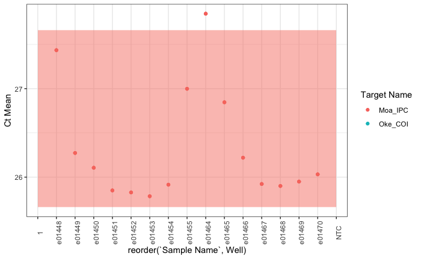

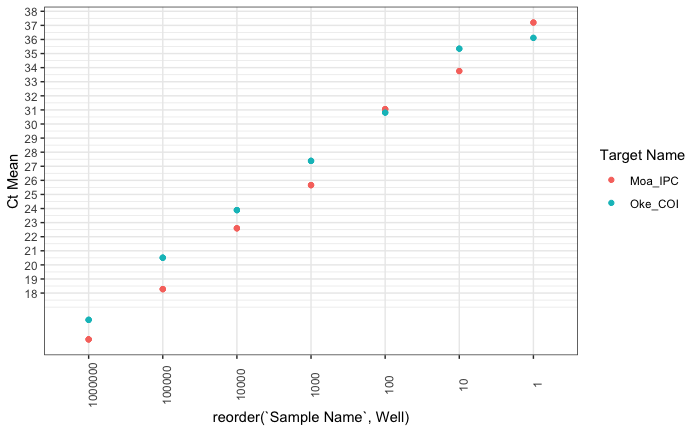

```r
NA
```

```r
fp <- "../data/qpcr/2022/"

fp %>%
  list.files() %>%
  .[str_detect(., ".xlsx")] -> xlsx_names

# Load everything into the Global Environment
xlsx_names %>%
  purrr::map(function(file_name){ # iterate through each file name

  read_xlsx(paste0(fp, file_name), sheet = "Results", skip = 34)

}) -> df_list1 # Assign to a list

plates2022 <- bind_rows(df_list1, .id = "plate")

# multiple quantities by 10 because of 1:10 dilution factor
# and 2 ul of diluted extract added to each well
plates2022_10x <- plates2022 %>%
  mutate(quant = (Quantity*10)/2)

# list of samples
list2022 <- plates2022_10x %>%
  filter(Task =="UNKNOWN") %>%
  dplyr::select(`Sample Name`) %>%
  unique()

list2022
```

| Sample Name |
| --- |
| e01192 |
| e01256 |
| e01264 |
| e01193 |
| e01257 |
| e01265 |
| e01194 |
| e01258 |
| e01266 |
| e01195 |

[output cut: 173 more lines]

Next steps: join metadata

```r
# read in 2022 metadata
```

[output not shown]

```r
meta2022 <- read_xlsx("../data/Amalga2022_cleanMetadata.xlsx")
```

[output not shown]

```r
meta2022
```

| Extraction ID | Sample Code | Project | Sample Label | transect | distance_from_pens | depth | time_of_day | replicate | Sample_Date | Sampler Initials | Metadata Reference | Extraction Initials | Ext_Date | Ext_Plate |
| --- | --- | --- | --- | --- | --- | --- | --- | --- | --- | --- | --- | --- | --- | --- |
| e01192 | 0m_surface_AM | Amalga 2022 | 0m_surface_AM | perpendicular | 0 | 0 | AM | 1 | 2022_05_05 | DBaetscher | Amalga_2022 | MP/CT | 2022-08-25 | 2022-09-01 |
| e01193 | 0m_surface_AM | Amalga 2022 | 0m_surface_AM | perpendicular | 0 | 0 | AM | 2 | 2022_05_05 | DBaetscher | Amalga_2022 | MP/CT | 2022-08-25 | 2022-09-01 |
| e01194 | 0m_surface_AM | Amalga 2022 | 0m_surface_AM | perpendicular | 0 | 0 | AM | 3 | 2022_05_05 | DBaetscher | Amalga_2022 | MP/CT | 2022-08-25 | 2022-09-01 |
| e01195 | 0m_10m_depth_AM | Amalga 2022 | 0m_10m_depth_AM | perpendicular | 0 | 10 | AM | 1 | 2022_05_05 | DBaetscher | Amalga_2022 | MP/CT | 2022-08-25 | 2022-09-01 |
| e01196 | 0m_10m_depth_AM | Amalga 2022 | 0m_10m_depth_AM | perpendicular | 0 | 10 | AM | 2 | 2022_05_05 | DBaetscher | Amalga_2022 | MP/CT | 2022-08-25 | 2022-09-01 |
| e01197 | 0m_10m_depth_AM | Amalga 2022 | 0m_10m_depth_AM | perpendicular | 0 | 10 | AM | 3 | 2022_05_05 | DBaetscher | Amalga_2022 | MP/CT | 2022-08-25 | 2022-09-01 |
| e01198 | 0m_surface | Amalga 2022 | 0m_surface | perpendicular | 0 | 0 | PM | 1 | 2022_05_10 | DBaetscher | Amalga_2022 | MP/CT | 2022-08-25 | 2022-09-01 |
| e01199 | 0m_surface | Amalga 2022 | 0m_surface | perpendicular | 0 | 0 | PM | 2 | 2022_05_10 | DBaetscher | Amalga_2022 | MP/CT | 2022-08-25 | 2022-09-01 |
| e01200 | 0m_surface | Amalga 2022 | 0m_surface | perpendicular | 0 | 0 | PM | 3 | 2022_05_10 | DBaetscher | Amalga_2022 | MP/CT | 2022-08-25 | 2022-09-01 |
| e01201 | 500m_surface | Amalga 2022 | 500m_surface | perpendicular | 500 | 0 | PM | 1 | 2022_05_10 | DBaetscher | Amalga_2022 | MP/CT | 2022-08-25 | 2022-09-01 |

[output cut: 278 more lines]

[output not shown]

```r
qpcr_meta2022_combined <- plates2022_10x %>%
```

[output not shown]

```r
  left_join(., meta2022, by = c("Sample Name" = "Extraction ID")) %>%
```

[output not shown]

```r
  filter(Task == "UNKNOWN" &
```

[output not shown]

```r
          !is.na(distance_from_pens))
```

[output not shown]

```r
qpcr_meta2022_combined %>%
```

[output not shown]

```r
  filter(`Target Name` == "Oke_COI" &
```

[output not shown]

```r
           transect == "perpendicular") %>%
```

[output not shown]

```r
  ggplot(aes(x = distance_from_pens, y = log(quant))) +
```

[output not shown]

```r
  geom_point(aes(color = time_of_day), alpha = 0.5) +
```

[output not shown]

```r
  facet_grid(cols = vars(transect), rows = vars(depth), space = "free", labeller = label_both) +
```

[output not shown]

[output not shown]

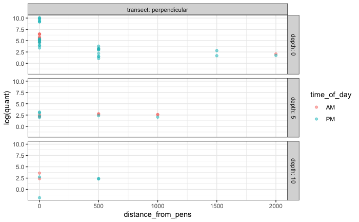

[output not shown]

```r
  theme_bw()
```

```r
list2022 %>%
```

[output not shown]

```r
  left_join(., meta2022, by = c("Sample Name" = "Extraction ID")) %>%
```

[output not shown]

```r
  filter(Sample_Date == "2022_05_05")
```

| Sample Name | Sample Code | Project | Sample Label | transect | distance_from_pens | depth | time_of_day | replicate | Sample_Date | Sampler Initials | Metadata Reference | Extraction Initials | Ext_Date | Ext_Plate |
| --- | --- | --- | --- | --- | --- | --- | --- | --- | --- | --- | --- | --- | --- | --- |
| e01192 | 0m_surface_AM | Amalga 2022 | 0m_surface_AM | perpendicular | 0 | 0 | AM | 1 | 2022_05_05 | DBaetscher | Amalga_2022 | MP/CT | 2022-08-25 | 2022-09-01 |
| e01264 | 500m_10m_depth_AM | Amalga 2022 | 500m_10m_depth_AM | perpendicular | 500 | 10 | AM | 1 | 2022_05_05 | DBaetscher | Amalga_2022 | MP/CT | 2022-08-25 | 2022-09-01 |
| e01193 | 0m_surface_AM | Amalga 2022 | 0m_surface_AM | perpendicular | 0 | 0 | AM | 2 | 2022_05_05 | DBaetscher | Amalga_2022 | MP/CT | 2022-08-25 | 2022-09-01 |
| e01265 | 500m_10m_depth_AM | Amalga 2022 | 500m_10m_depth_AM | perpendicular | 500 | 10 | AM | 2 | 2022_05_05 | DBaetscher | Amalga_2022 | MP/CT | 2022-08-25 | 2022-09-01 |
| e01194 | 0m_surface_AM | Amalga 2022 | 0m_surface_AM | perpendicular | 0 | 0 | AM | 3 | 2022_05_05 | DBaetscher | Amalga_2022 | MP/CT | 2022-08-25 | 2022-09-01 |
| e01258 | 500m_surface_AM | Amalga 2022 | 500m_surface_AM | perpendicular | 500 | 0 | AM | 1 | 2022_05_05 | DBaetscher | Amalga_2022 | MP/CT | 2022-08-25 | 2022-09-01 |
| e01266 | 500m_10m_depth_AM | Amalga 2022 | 500m_10m_depth_AM | perpendicular | 500 | 10 | AM | 3 | 2022_05_05 | DBaetscher | Amalga_2022 | MP/CT | 2022-08-25 | 2022-09-01 |
| e01195 | 0m_10m_depth_AM | Amalga 2022 | 0m_10m_depth_AM | perpendicular | 0 | 10 | AM | 1 | 2022_05_05 | DBaetscher | Amalga_2022 | MP/CT | 2022-08-25 | 2022-09-01 |
| e01259 | 500m_surface_AM | Amalga 2022 | 500m_surface_AM | perpendicular | 500 | 0 | AM | 2 | 2022_05_05 | DBaetscher | Amalga_2022 | MP/CT | 2022-08-25 | 2022-09-01 |
| e01267 | 1000m_surface_AM | Amalga 2022 | 1000m_surface_AM | perpendicular | 1000 | 0 | AM | 1 | 2022_05_05 | DBaetscher | Amalga_2022 | MP/CT | 2022-08-25 | 2022-09-01 |

[output cut: 164 more lines]

[output not shown]

[output not shown]

```r
samples_meta22 <- list2022 %>%
```

[output not shown]

```r
  left_join(., meta2022, by = c("Sample Name" = "Extraction ID")) #%>%
```

[output not shown]

```r
  #filter(Sample_Date == "2022_05_05")
```

[output not shown]

Double check that there are no spatial patterns evident in the samples that remained inhibited:

```r
inhibited220 <- c("e01192", "e01256", "e01264", "e01271", "e01272", "e01312", "e01319", "e01320", "e01328", "e01335", "e01336", "e01342", "e01343", "e01366", "e01400", "e01416", "e01417", "e01438", "e01439", "e01464")
```

[output not shown]

```r
# make that a dataframe
```

[output not shown]

```r
inhibited_samples_22 <- as.data.frame(inhibited220) %>%
```

[output not shown]

```r
  rename(`Sample Name` = inhibited220)
```

[output not shown]

```r
# add metadata
```

[output not shown]

```r
inhibited_df22 <- inhibited_samples_22 %>%
```

[output not shown]

```r
  left_join(., samples_meta22) %>%
```

[output not shown]

```r
  filter(Sample_Date == "2022_05_05")
```

[output not shown]

```r
# look for spatial patterns in inhibited samples...
```

[output not shown]

```r
inhibited_df22 %>%
```

[output not shown]

```r
  ggplot(aes(x = distance_from_pens, y = -1*depth, color = time_of_day)) +
```

[output not shown]

```r
  geom_jitter(width = 10, height = 2) +
```

[output not shown]

[output not shown]

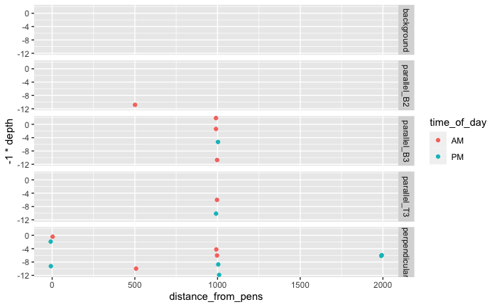

```r
  facet_grid(rows = vars(transect))
```

**some of the inhibited samples are not from the 5/5/22 sampling date (but only 2).

```r
# zooming in on the samples at 0 m distance,
```

[output not shown]

```r
# were there sample replicates that did amplify/ were not inhibited?
```

[output not shown]

```r
inhibited_df22 %>%
```

[output not shown]

```r
  filter(distance_from_pens == 0)
```

| Sample Name | Sample Code | Project | Sample Label | transect | distance_from_pens | depth | time_of_day | replicate | Sample_Date | Sampler Initials | Metadata Reference | Extraction Initials | Ext_Date | Ext_Plate |
| --- | --- | --- | --- | --- | --- | --- | --- | --- | --- | --- | --- | --- | --- | --- |
| e01192 | 0m_surface_AM | Amalga 2022 | 0m_surface_AM | perpendicular | 0 | 0 | AM | 1 | 2022_05_05 | DBaetscher | Amalga_2022 | MP/CT | 2022-08-25 | 2022-09-01 |
| e01312 | 0m_surface_PM | Amalga 2022 | 0m_surface_PM | perpendicular | 0 | 0 | PM | 2 | 2022_05_05 | DBaetscher | Amalga_2022 | MP | 2022-09-08 | 2022-10-01 |
| e01319 | 0m_10m_depth_PM | Amalga 2022 | 0m_10m_depth_PM | perpendicular | 0 | 10 | PM | 3 | 2022_05_05 | DBaetscher | Amalga_2022 | MP | 2022-09-08 | 2022-10-01 |

[output not shown]

So few data points for Oke_COI compared to the total number of samples analyzed.

```r
# previous qpcr data
```

[output not shown]

```r
prev_qpcr <- read_xlsx("../data/2022_qPCR_results_combined.xlsx")
```

[output not shown]

```r
p_qpcr2 <- prev_qpcr %>%
```

[output not shown]

```r
  filter(Task != "STANDARD") %>%
```

[output not shown]

```r
  mutate(new_name = paste0("e0",`Sample Name`)) %>%
```

[output not shown]

```r
  dplyr::select(new_name, CT, Quantity)
```

[output not shown]

```r
tmp3 <- qpcr_meta2022_combined %>%
```

[output not shown]

```r
  filter(`Target Name` == "Oke_COI") %>%
```

[output not shown]

```r
  left_join(p_qpcr2, by = c("Sample Name" = "new_name")) %>%
```

[output not shown]

```r
  dplyr::select(`Sample Name`, CT.x, CT.y, Quantity.x, Quantity.y) %>%
```

[output not shown]

```r
  unique()
tmp3$CT.x <- as.numeric(tmp3$CT.x)
tmp3$CT.y <- as.numeric(tmp3$CT.y)
tmp3 %>%
```

[output not shown]

```r
  ggplot(aes(x = CT.x, y = CT.y)) +
```

[output not shown]

```r
  geom_point() +
```

[output not shown]

```r
  geom_abline(slope = 1, color = "blue") +
```

[output not shown]

```r
  labs(x = "qPCR CT values w/ 1:10 dilution",
```

[output not shown]

```r
       y = "qPCR CT values without dilution") +
```

[output not shown]

```r
  scale_x_continuous(limits = c(25, 45)) +
```

[output not shown]

```r
  scale_y_continuous(limits = c(25, 45)) +
```

[output not shown]

```r
  theme(
```

[output not shown]

```r
    axis.title.x = element_text(margin = margin(t = 10)),
```

[output not shown]

```r
        axis.title.y = element_text(margin = margin(r = 10)),
```

[output not shown]

[output not shown]

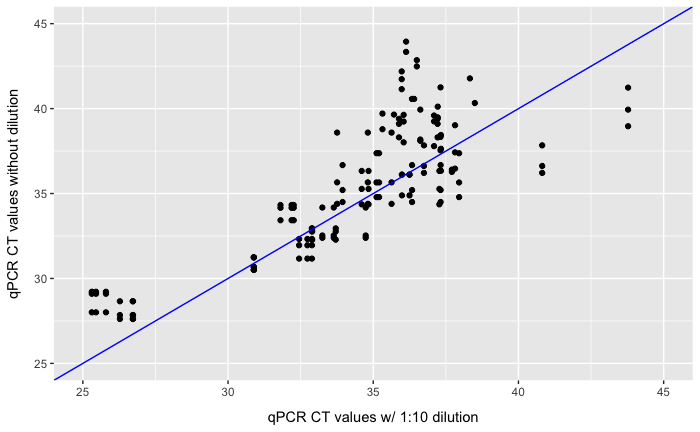

```r
  )
```

Welp, that clearly shows that the diluted samples amplify at lower CT values when they deviate from the prior qPCR analysis. That’s great. It means the inhibition dilutions are working as hoped and that the data otherwise appear just as they did previously.

There are two samples that amplify later in the dilutions compared to the original qPCR.

```r
#qpcr_inhibition_test("../data/qpcr/2022/2023-11-03_Amalga2022_inhibition_test_plate1.xlsx")
```

[output not shown]

There are hints of remaining inhibition for just a few samples. Good to look at replicates and determine whether there’s something else I need to do.

Can I look at the inhibition across all 2022 plates?

```r
# test for inhibition
```

[output not shown]

```r
        data2022_plot <- qpcr_meta2022_combined %>%
```

[output not shown]

```r
          filter(Task != "STANDARD") %>%
```

[output not shown]

```r
          ggplot(aes(x = reorder(`Sample Name`, Well), y = `Ct Mean` , color = `Target Name`)) +
```

[output not shown]

```r
          geom_point() +
```

[output not shown]

```r
          theme_bw() +
```

[output not shown]

```r
          theme(
```

[output not shown]

```r
            axis.text.x = element_text(angle = 90)
```

[output not shown]

```r
          ) +
```

[output not shown]

```r
          #facet_grid(rows = vars(`Target Name`))  +
```

[output not shown]

```r
          scale_y_continuous(breaks = seq(18,45, 1))
```

[output not shown]

[output not shown]

```r
qpcr_meta2022_combined %>%
```

[output not shown]

```r
          filter(Task != "STANDARD") %>%
```

[output not shown]

```r
  ggplot(aes(x = reorder(`Sample Name`, Well), y = `Ct Mean` , color = `Target Name`)) +
```

[output not shown]

```r
          geom_point() +
```

[output not shown]

```r
          theme_bw() +
```

[output not shown]

```r
          theme(
```

[output not shown]

```r
            axis.text.x = element_text(angle = 90)
```

[output not shown]

```r
          ) +
```

[output not shown]

```r
          #facet_grid(rows = vars(`Target Name`))  +
```

[output not shown]

[output not shown]

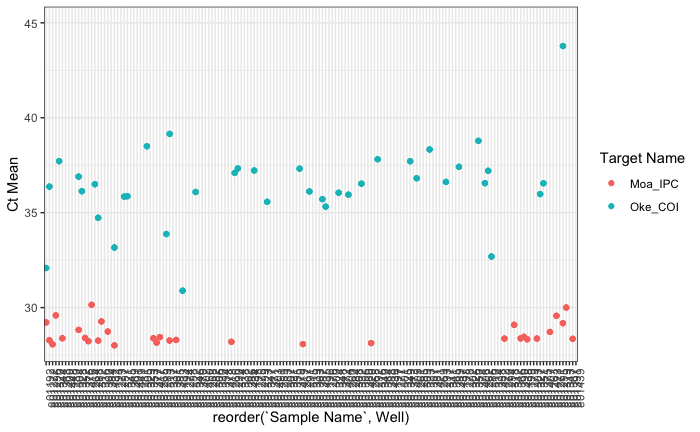

[output not shown]

```r
          scale_y_continuous(limits = c(28,45))
```

```r
qpcr_meta2022_combined %>%
```

[output not shown]

```r
          filter(Task != "STANDARD" &
```

[output not shown]

```r
                   `Ct Mean` > 29) %>%
```

[output not shown]

```r
   ggplot(aes(x = reorder(`Sample Name`, Well), y = `Ct Mean` , color = `Target Name`)) +
```

[output not shown]

```r
          geom_point() +
```

[output not shown]

```r
          theme_bw() +
```

[output not shown]

```r
          theme(
```

[output not shown]

```r
            axis.text.x = element_text(angle = 90)
```

[output not shown]

[output not shown]

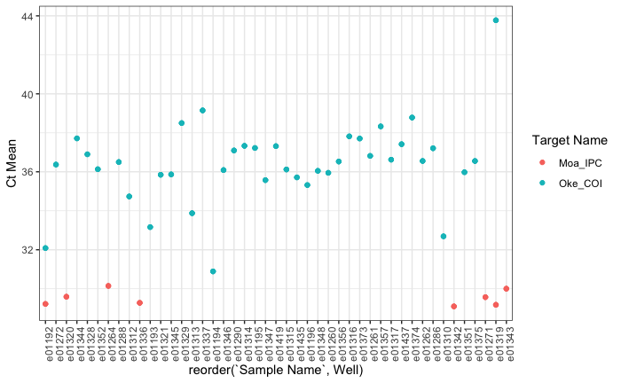

```r
          )
```

So that’s as few as 8 samples.

Summarize across samples based on metadata

```r
df_w_meta2022 <- qpcr_meta2022_combined %>%
```

[output not shown]

```r
  filter(`Target Name` == "Oke_COI" &
```

[output not shown]

```r
           Task == "UNKNOWN") %>%
```

[output not shown]

```r
  dplyr::select(`Sample Name`, CT, Quantity, quant, `Sample Code`, transect, distance_from_pens, depth, time_of_day, Sample_Date) %>%
```

[output not shown]

```r
  filter(Sample_Date == "2022_05_05")
```

[output not shown]

```r
df_w_meta2022 %>%
```

[output not shown]

```r
  filter(depth == "0" &
```

[output not shown]

```r
           transect == "perpendicular") %>%
```

[output not shown]

```r
  ggplot(aes(x = distance_from_pens, y = log10(Quantity), color = time_of_day)) +
```

[output not shown]

```r
  geom_point() +
```

[output not shown]

```r
  facet_grid(rows = vars(time_of_day)) +
```

[output not shown]

```r
  #facet_grid(cols = vars(transect), scales = "free") +
```

[output not shown]

```r
  theme_bw() +
```

[output not shown]

```r
  theme(
```

[output not shown]

```r
    axis.text.x = element_text(angle = 90)
```

[output not shown]

```r
          ) +
```

[output not shown]

[output not shown]

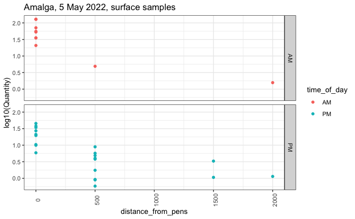

[output not shown]

```r
  labs(title = "Amalga, 5 May 2022, surface samples")
```

```r
#ggsave("pdf_outputs/amalga2022_perpendicularTransect.pdf", width = 7, height = 5)
```

[output not shown]

```r
df_w_meta2022 %>%
```

[output not shown]

```r
  #filter(depth == "0") %>%
```

[output not shown]

```r
  ggplot(aes(x = distance_from_pens, y = log10(Quantity), shape = time_of_day, color = time_of_day)) +
```

[output not shown]

```r
  geom_point(size = 3, alpha = 0.6) +
```

[output not shown]

```r
  facet_grid(rows = vars(depth), labeller = "label_both") +
```

[output not shown]

```r
  #facet_grid(cols = vars(transect), scales = "free") +
```

[output not shown]

```r
  theme_bw() +
```

[output not shown]

```r
  theme(
```

[output not shown]

```r
    axis.text.x = element_text(angle = 90)
```

[output not shown]

```r
          ) +
```

[output not shown]

```r
  labs(title = "Amalga, 5 May 2022") +
```

[output not shown]

```r
  scale_shape_manual(values = c(16,18)) +
```

[output not shown]

[output not shown]

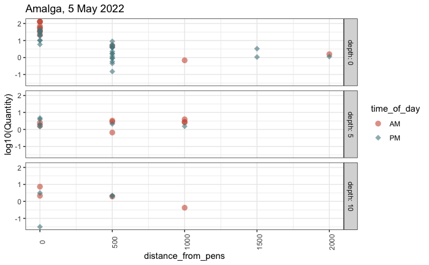

[output not shown]

```r
  scale_color_manual(values = mycols)
```

```r
df_w_meta2022 %>%
```

[output not shown]

```r
  filter(transect != "perpendicular") %>%
```

[output not shown]

```r
  ggplot(aes(x = distance_from_pens, y = log10(Quantity), shape = time_of_day, color = time_of_day)) +
```

[output not shown]

```r
  geom_point(size = 3) +
```

[output not shown]

```r
  facet_grid(rows = vars(depth), labeller = "label_both") +
```

[output not shown]

```r
  #facet_grid(cols = vars(transect), scales = "free") +
```

[output not shown]

```r
  theme_bw() +
```

[output not shown]

```r
  theme(
```

[output not shown]

```r
    axis.text.x = element_text(angle = 90)
```

[output not shown]

```r
          ) +
```

[output not shown]

```r
  labs(title = "Amalga, 5 May 2022") +
```

[output not shown]

```r
  scale_shape_manual(values = c(1,2)) +
```

[output not shown]

[output not shown]

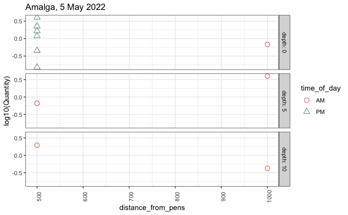

[output not shown]

```r
  scale_color_manual(values = mycols)
```

To dos: 1. Create a single joined dataframe with qPCR data from both 2022 and 2021 2. Evaluating the quantities in relation to the LOD/LOQ 3. Conclusions about detection distance, quantification distance, differences between years, depth, perpendicular vs. parallel transects

Results

number of samples (2021, 2022)

qPCR number of detections above the LOD (within what distance?) number of samples with LOQ number of inhibited samples (and locations - figure) no positive detections in the negative controls (maybe one??) no positive detections in the extraction blanks (if tested?)

```r
# 2021 data - including the inhibited samples rerun as dilutions
```

[output not shown]

```r
df2021 <- combined_data %>%
```

[output not shown]

```r
  filter(`Target Name` == "Oke_COI" &
```

[output not shown]

```r
           Task == "UNKNOWN") %>%
```

[output not shown]

```r
  dplyr::select(`Sample Name`, CT, quant_per_ul)
```

[output not shown]

[output not shown]

[output not shown]

```r
# 2022 data
```

[output not shown]

```r
df2022 <- plates2022_10x %>%
```

[output not shown]

```r
  filter(`Target Name` == "Oke_COI" &
```

[output not shown]

```r
           Task == "UNKNOWN") %>%
```

[output not shown]

```r
  rename(quant_per_ul = quant) %>%
```

[output not shown]

```r
  dplyr::select(`Sample Name`, CT, quant_per_ul)
```

[output not shown]

```r
# combine those
```

[output not shown]

```r
combo_df <- bind_rows(df2021, df2022) %>%
```

[output not shown]

```r
  rename(sample = `Sample Name`)
```

[output not shown]

```r
slim_m2021 <- clean_meta %>%
```

[output not shown]

```r
  mutate(time_of_day = location) %>%
```

[output not shown]

```r
  mutate(depth = 0) %>%
```

[output not shown]

```r
  mutate(transect = "perpendicular") %>%
```

[output not shown]

```r
  rename(distance_from_pens = distance) %>%
```

[output not shown]

```r
  dplyr::select(-location, -type, -dist_grp) %>%
```

[output not shown]

```r
  mutate(sample_date = "2021_05_10")
```

[output not shown]

```r
slim_m2022 <- meta2022 %>%
```

[output not shown]

```r
  rename(sample = `Extraction ID`, label = `Sample Code`, sample_date = Sample_Date) %>%
```

[output not shown]

```r
  dplyr::select(sample, label, distance_from_pens, time_of_day, depth, transect, sample_date) %>%
```

[output not shown]

```r
  mutate(tide = ifelse(time_of_day == "AM", "outgoing", "incoming"))
```

[output not shown]

[output not shown]

```r
metadata_both_years <- bind_rows(slim_m2021, slim_m2022)
```

[output not shown]

```r
merged_df_both_years <- combo_df %>%
```

[output not shown]

```r
  left_join(., metadata_both_years) %>%
```

[output not shown]

```r
  filter(sample_date %in% c("2021_05_10", "2022_05_05")) %>%
```

[output not shown]

```r
  mutate(year = ifelse(sample_date == "2021_05_10", "2021", "2022")) %>%
```

[output not shown]

```r
  filter(distance_from_pens != 100) %>%
```

[output not shown]

```r
    mutate(log_dna_ul = log10(quant_per_ul))
```

[output not shown]

```r
merged_df_both_years %>%
```

[output not shown]

```r
  filter(year == "2022" & depth == 0)
```

| sample | CT | quant_per_ul | label | tide | distance_from_pens | time_of_day | depth | transect | sample_date | year | log_dna_ul |
| --- | --- | --- | --- | --- | --- | --- | --- | --- | --- | --- | --- |
| e01192 | 32.188362 | 278.2202339 | 0m_surface_AM | outgoing | 0 | AM | 0 | perpendicular | 2022_05_05 | 2022 | 2.4443887 |
| e01192 | 31.80571 | 356.3339615 | 0m_surface_AM | outgoing | 0 | AM | 0 | perpendicular | 2022_05_05 | 2022 | 2.5518572 |
| e01192 | 32.261612 | 265.3483582 | 0m_surface_AM | outgoing | 0 | AM | 0 | perpendicular | 2022_05_05 | 2022 | 2.4238164 |
| e01193 | 33.708157 | 104.1242981 | 0m_surface_AM | outgoing | 0 | AM | 0 | perpendicular | 2022_05_05 | 2022 | 2.0175521 |
| e01193 | 32.88484 | 177.3300552 | 0m_surface_AM | outgoing | 0 | AM | 0 | perpendicular | 2022_05_05 | 2022 | 2.2487823 |
| e01193 | 32.897076 | 175.9322357 | 0m_surface_AM | outgoing | 0 | AM | 0 | perpendicular | 2022_05_05 | 2022 | 2.2453454 |
| e01194 | 30.890171 | 644.1510010 | 0m_surface_AM | outgoing | 0 | AM | 0 | perpendicular | 2022_05_05 | 2022 | 2.8089877 |
| e01194 | 30.891844 | 643.4545898 | 0m_surface_AM | outgoing | 0 | AM | 0 | perpendicular | 2022_05_05 | 2022 | 2.8085179 |
| e01194 | 30.88471 | 646.4297485 | 0m_surface_AM | outgoing | 0 | AM | 0 | perpendicular | 2022_05_05 | 2022 | 2.8105213 |
| e01258 | Undetermined | NA | 500m_surface_AM | outgoing | 500 | AM | 0 | perpendicular | 2022_05_05 | 2022 | NA |

[output cut: 152 more lines]

[output not shown]

```r
# start exploring that data
```

[output not shown]

```r
merged_df_both_years %>%
```

[output not shown]

```r
  filter(!is.na(distance_from_pens) &
```

[output not shown]

```r
           transect == "perpendicular" &
```

[output not shown]

```r
           depth == 0) %>%
```

[output not shown]

```r
  ggplot(aes(x = distance_from_pens, y = log_dna_ul, shape = tide, color = tide)) +
```

[output not shown]

```r
  geom_point(size = 3, alpha = 0.65) +
```

[output not shown]

```r
  facet_grid(rows = vars(year)) +
```

[output not shown]

```r
  theme_bw() +
```

[output not shown]

```r
  scale_shape_manual(values = c(16, 18)) +
```

[output not shown]

```r
  scale_color_manual(values = mycols) +
```

[output not shown]

```r
  labs(x = "Distance from pens (m)",
```

[output not shown]

```r
       y = "DNA copies/uL (log10)") +
```

[output not shown]

```r
  theme(
```

[output not shown]

```r
    axis.title.x = element_text(margin = margin(t = 10)),
```

[output not shown]

```r
    axis.title.y = element_text(margin = margin(r = 10))
```

[output not shown]

[output not shown]

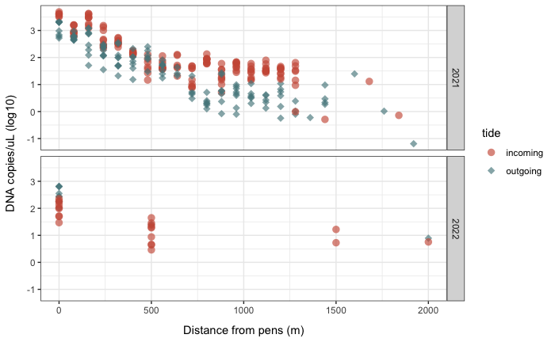

[output not shown]

```r
  )
```

Okay, that’s kind of useful. Very little to talk about with the 2022 samples. There’s one outlier for the incoming tide at 0m that I don’t like - it would be nice to take a look at the replicates.

```r
merged_df_both_years %>%
```

[output not shown]

```r
  filter(sample_date == "2022_05_05") %>%
```

[output not shown]

```r
  mutate(detection = ifelse(CT == "Undetermined", "no", "yes")) %>%
```

[output not shown]

```r
  group_by(detection) %>%
```

[output not shown]

```r
  tally()
```

| detection | n |
| --- | --- |
| no | 425 |
| yes | 61 |

[output not shown]

So many non-detections!

```r
merged_df_both_years %>%
```

[output not shown]

```r
  filter(sample_date == "2021_05_10") %>%
```

[output not shown]

```r
  mutate(detection = ifelse(CT == "Undetermined", "no", "yes")) %>%
```

[output not shown]

```r
  group_by(detection) %>%
```

[output not shown]

```r
  tally()
```

| detection | n |
| --- | --- |
| no | 198 |
| yes | 269 |

[output not shown]

Much more equal, with slightly more detections.

I think I’ll basically tell a story with the 2021 data and then use the 2022 data to back up statements about depth distribution.

```r
merged_df_both_years %>%
```

[output not shown]

```r
  filter(label != "blank" | label == "background") %>%
```

[output not shown]

```r
  mutate(distance_from_pens = ifelse(str_detect(transect, "_B"), -distance_from_pens, distance_from_pens)) %>%
```

[output not shown]

```r
  mutate(x_dist = ifelse(transect == "perpendicular", distance_from_pens, NA)) %>%
```

[output not shown]

```r
  mutate(y_dist = ifelse(str_detect(transect,"parallel"), distance_from_pens, NA)) %>%
```

[output not shown]

```r
  mutate(y_dist = ifelse(is.na(y_dist), 0, y_dist)) %>%
```

[output not shown]

```r
  mutate(x_dist = ifelse(is.na(x_dist), 1000, x_dist)) %>%
```

[output not shown]

```r
  group_by(year, tide, depth) %>%
```

[output not shown]

```r
  tally()
```

| year | tide | depth | n |
| --- | --- | --- | --- |
| 2021 | incoming | 0 | 233 |
| 2021 | outgoing | 0 | 234 |
| 2022 | incoming | 0 | 81 |
| 2022 | incoming | 5 | 81 |
| 2022 | incoming | 10 | 81 |
| 2022 | outgoing | 0 | 81 |
| 2022 | outgoing | 5 | 81 |
| 2022 | outgoing | 10 | 81 |

[output not shown]

```r
merged_df_both_years %>%
```

[output not shown]

```r
  filter(label != "blank" & !str_detect(label, "background")) %>%
```

[output not shown]

```r
  mutate(distance_from_pens = ifelse(str_detect(transect, "_B"), -distance_from_pens, distance_from_pens)) %>%
```

[output not shown]

```r
  mutate(x_dist = ifelse(transect == "perpendicular", distance_from_pens, NA)) %>%
```

[output not shown]

```r
  mutate(y_dist = ifelse(str_detect(transect,"parallel"), distance_from_pens, NA)) %>%
```

[output not shown]

```r
  mutate(y_dist = ifelse(is.na(y_dist), 0, y_dist)) %>%
```

[output not shown]

```r
  mutate(x_dist = ifelse(is.na(x_dist), 1000, x_dist)) %>%
```

[output not shown]

```r
  group_by(year, tide, depth) %>%
```

[output not shown]

```r
  tally()
```

| year | tide | depth | n |
| --- | --- | --- | --- |
| 2021 | incoming | 0 | 233 |
| 2021 | outgoing | 0 | 234 |
| 2022 | incoming | 0 | 81 |
| 2022 | incoming | 5 | 81 |
| 2022 | incoming | 10 | 81 |
| 2022 | outgoing | 0 | 81 |
| 2022 | outgoing | 5 | 81 |
| 2022 | outgoing | 10 | 81 |

[output not shown]

## Stats for distance & tide

Are data normally distributed?

```r
for_mod2021 <- merged_df_both_years %>%
```

[output not shown]

```r
  filter(sample_date == "2021_05_10" &
```

[output not shown]

```r
           distance_from_pens != 100) %>% # bec this is between the creek and the pens
```

[output not shown]

```r
library(ggpubr)
```

[output not shown]

[output not shown]

```r
shapiro.test(for_mod2021$log_dna_ul)
```

```
    Shapiro-Wilk normality test

data:  for_mod2021$log_dna_ul
W = 0.98787, p-value = 0.02323
```

```r
# model 1: copy number and distance
mod1 <- lm(data = for_mod2021, log_dna_ul ~ distance_from_pens)

# model 2: distance and tide
mod2 <- lm(data = for_mod2021, log_dna_ul ~ distance_from_pens + tide)

# now compare the models with anova
anova(mod1, mod2)
```

```
Analysis of Variance Table

Model 1: log_dna_ul ~ distance_from_pens
Model 2: log_dna_ul ~ distance_from_pens + tide
  Res.Df    RSS Df Sum of Sq      F    Pr(>F)
1    267 79.205
2    266 56.685  1     22.52 105.68 < 2.2e-16 ***
---
Signif. codes:  0 ‘***’ 0.001 ‘**’ 0.01 ‘*’ 0.05 ‘.’ 0.1 ‘ ’ 1
```

```r
summary(mod2)
```

```
Call:
lm(formula = log_dna_ul ~ distance_from_pens + tide, data = for_mod2021)

Residuals:
     Min       1Q   Median       3Q      Max
-1.15499 -0.29317  0.03599  0.32653  1.68978

Coefficients:
                     Estimate Std. Error t value Pr(>|t|)
(Intercept)         3.1924639  0.0581049   54.94   <2e-16 ***
distance_from_pens -0.0018164  0.0000656  -27.69   <2e-16 ***
tideoutgoing       -0.5814644  0.0565630  -10.28   <2e-16 ***
---
Signif. codes:  0 ‘***’ 0.001 ‘**’ 0.01 ‘*’ 0.05 ‘.’ 0.1 ‘ ’ 1

Residual standard error: 0.4616 on 266 degrees of freedom
  (198 observations deleted due to missingness)
Multiple R-squared:  0.7611,    Adjusted R-squared:  0.7593
F-statistic: 423.6 on 2 and 266 DF,  p-value: < 2.2e-16
```

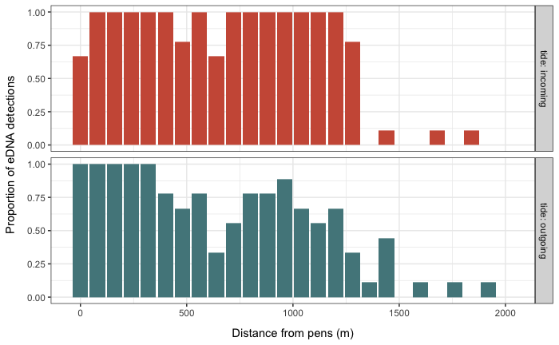

```r
merged_df_both_years %>%
 filter(!is.na(distance_from_pens) &
           year == 2021 &
          distance_from_pens != 100) %>%
  group_by(tide, distance_from_pens) %>%
  mutate(detection = ifelse(is.na(quant_per_ul), 0, 1)) %>%
  summarise(n_detections = sum(detection)/9) %>%
  ggplot(aes(x = distance_from_pens, y = n_detections, fill = tide)) +
  geom_bar(stat = "identity") +
  facet_grid(rows = vars(tide), labeller = label_both) +
  theme_bw() +
  scale_shape_manual(values = c(1,2)) +
  scale_fill_manual(values = mycols) +
  labs(x = "Distance from pens (m)",
       y = "Proportion of eDNA detections") +
  theme(
    axis.title.x = element_text(margin = margin(t = 10)),
    axis.title.y = element_text(margin = margin(r = 10)),
    legend.position = "none"
  )
ggsave("pdf_outputs/eDNA_detections2021.png", width = 6, height = 4)
```

```r
# max detection distance:
merged_df_both_years %>%
  filter(!is.na(distance_from_pens) &
           transect == "perpendicular" &
           depth == 0 &
           sample_date == "2021_05_10" &
           CT != "Undetermined",
         distance_from_pens > 1800)
```

| sample | CT | quant_per_ul | label | tide | distance_from_pens | time_of_day | depth | transect | sample_date | year | log_dna_ul |
| --- | --- | --- | --- | --- | --- | --- | --- | --- | --- | --- | --- |
| e00121 | 37.805637 | 0.72183365 | 1840m | incoming | 1840 | AM | 0 | perpendicular | 2021_05_10 | 2021 | -0.1415629 |
| e00179 | 42.22208 | 0.06433138 | 1920m | outgoing | 1920 | PM | 0 | perpendicular | 2021_05_10 | 2021 | -1.1915772 |

```r
NA
```

1920m maximum detection distance from 2021

both of the farthest detections are technically below the LOD.

```r
merged_df_both_years %>%
  filter(!is.na(distance_from_pens) &
           transect == "perpendicular" &
           depth == 0 &
           sample_date == "2021_05_10" &
           CT != "Undetermined" &
           quant_per_ul > 50) %>%
  group_by(sample, distance_from_pens) %>%
  summarise(mean_copies = mean(quant_per_ul)) %>%
  arrange(distance_from_pens)
```

| sample | distance_from_pens | mean_copies |
| --- | --- | --- |
| e00050 | 0 | 4410.55603 |
| e00051 | 0 | 3474.04150 |
| e00134 | 0 | 2109.63342 |
| e00135 | 0 | 605.46850 |
| e00136 | 0 | 1658.34658 |
| e00052 | 80 | 818.44806 |
| e00053 | 80 | 724.38617 |
| e00054 | 80 | 1584.83960 |
| e00137 | 80 | 549.85415 |
| e00138 | 80 | 713.53299 |

[output cut: 44 more lines]

How many samples above the LOD/LOQ?

```r
merged_df_both_years %>%
  #filter(distance_from_pens < 1001) %>%
  group_by(year) %>%
  filter(quant_per_ul > 25) %>% # a LOD of 10 copies/rxn = 5 copies/ 2 ul rxn
  tally()
```

| year | n |
| --- | --- |
| 2021 | 186 |
| 2022 | 21 |

```r
NA
```

```r
merged_df_both_years %>%
   filter(quant_per_ul < 5)  %>%
  group_by(distance_from_pens, year) %>%
  tally()
```

| distance_from_pens | year | n |
| --- | --- | --- |
| 0 | 2022 | 1 |
| 500 | 2022 | 6 |
| 720 | 2021 | 3 |
| 800 | 2021 | 6 |
| 880 | 2021 | 3 |
| 960 | 2021 | 4 |
| 1000 | 2022 | 2 |
| 1040 | 2021 | 5 |
| 1120 | 2021 | 5 |
| 1200 | 2021 | 3 |

[output cut: 6 more lines]

```r
NA
```

```r
merged_df_both_years %>%
  filter(year == 2021 &
           !is.na(tide) &
           distance_from_pens != 100 &
           !is.na(quant_per_ul)) %>%
  group_by(sample) %>%
  arrange(distance_from_pens) %>%
  mutate(mean_eDNA = mean(quant_per_ul)) %>%
  dplyr::select(distance_from_pens, tide, mean_eDNA) %>%
  unique() %>%
  ungroup() %>%
  group_by(tide) %>%
  mutate(cum_dna = sum(mean_eDNA)) %>%
  mutate(prop_dna = mean_eDNA/cum_dna)
```

| sample | distance_from_pens | tide | mean_eDNA | cum_dna | prop_dna |
| --- | --- | --- | --- | --- | --- |
| e00134 | 0 | outgoing | 2.109633e+03 | 9699.007 | 2.175102e-01 |
| e00051 | 0 | incoming | 3.474042e+03 | 24530.498 | 1.416213e-01 |
| e00136 | 0 | outgoing | 1.658347e+03 | 9699.007 | 1.709811e-01 |
| e00050 | 0 | incoming | 4.410556e+03 | 24530.498 | 1.797989e-01 |
| e00135 | 0 | outgoing | 6.054685e+02 | 9699.007 | 6.242582e-02 |
| e00052 | 80 | incoming | 8.184481e+02 | 24530.498 | 3.336451e-02 |
| e00053 | 80 | incoming | 7.243862e+02 | 24530.498 | 2.953002e-02 |
| e00054 | 80 | incoming | 1.584840e+03 | 24530.498 | 6.460691e-02 |
| e00137 | 80 | outgoing | 5.498542e+02 | 9699.007 | 5.669180e-02 |
| e00138 | 80 | outgoing | 7.135330e+02 | 9699.007 | 7.356763e-02 |

[output cut: 95 more lines]

Did I qPCR any of the extraction blanks?

```r
df_for_3d <- merged_df_both_years %>%
  filter(year == "2022") %>%
  mutate(distance_from_pens = ifelse(str_detect(transect, "_B"), -distance_from_pens, distance_from_pens)) %>%
  mutate(x_dist = ifelse(transect == "perpendicular", distance_from_pens, NA)) %>%
  mutate(y_dist = ifelse(str_detect(transect,"parallel"), distance_from_pens, NA)) %>%
  mutate(y_dist = ifelse(is.na(y_dist), 0, y_dist)) %>%
  mutate(x_dist = ifelse(is.na(x_dist), 1000, x_dist)) %>%
  mutate(log_quant = log10(quant_per_ul)) %>%
  mutate(depth = ifelse(depth != 0, -1*depth, depth))
```